# Transition Network Analysis (TNA) Tutorial

## Introduction

Transition Network Analysis (TNA) represents a novel methodological approach that captures the temporal and relational dynamics of unfolding processes. The core principle involves representing transition matrices between events as graphs, enabling researchers to leverage graph theory and network analysis comprehensively.

TNA functions as a sophisticated combination of process mining and network analysis. Where process mining typically generates sequential maps, TNA represents these through network analysis — but with considerably greater analytical depth. The method applies network analysis to capture structure, time, and relationships holistically. Compared to traditional process mining models, TNA incorporates network measures at node, edge, and graph levels, revealing which events hold importance through centrality measures, which transitions prove central, and which processes demonstrate greater connectivity. The method extends beyond standard network analysis by clustering sub-networks into different network constellations representing typical temporal event patterns — often called tactics.

A distinctive innovation involves statistical validation techniques unavailable in conventional approaches. These include edge verification through bootstrapping, network comparison via permutation testing, and centrality verification through case-dropping methods. These statistical techniques introduce rigor and validation at each analytical step, enabling researchers to verify which edges demonstrate replicability and confirm that inferences remain valid rather than chance artifacts.

### Why TNA?

Learning operates as a complex dynamic system — a collection of interconnected components interacting across time where interactions can enhance, impede, amplify, or reinforce each other. These dynamic interactions generate emergent behaviors that resist full understanding through analyzing individual components in isolation. Such interactions frequently produce processes exceeding the simple sum of their parts, exhibiting non-linear dynamics.

For example, motivation catalyzes achievement, which subsequently catalyzes enhanced engagement, enjoyment, and motivation. These interdependencies, feedback loops, and non-linear dynamics create inherent complexity requiring modeling methods transcending traditional linear approaches. TNA, functioning as a dynamic probabilistic model, addresses these limitations by capturing uncertainties through directional probabilities between learning events. The method accommodates the non-linear, evolving character of learning processes while capturing the constellations and emergent patterns defining or shaping learning processes.

### The Building Blocks of TNA

TNA's foundational elements are transitions between events comprising transition processes. A transition represents a conditional relationship between one occurrence and another — from A to B (a contingency). TNA models transitions in sequential data to compute transition probabilities between events. The resulting transition matrix becomes a weighted directed network where weights represent transition probabilities between events and direction indicates transition direction.

- **Nodes (V)** represent different learning events — watching videos, taking quizzes, submitting assignments — or alternatively, states, dialogue moves, collaborative roles, motivation states, or any event representable as sequence units.
- **Edges (E)** represent transitions between activities, displaying direction from one activity to the next.
- **Weights (W)** represent transitioning probabilities between events or states.

This tutorial demonstrates the complete TNA workflow using the Python `tna` package — from data preparation through model building, visualization, pruning, pattern detection, centrality analysis, community detection, bootstrapping, and group comparison. This tutorial replicates the R TNA tutorial by Saqr & Lopez-Pernas (2025) using the Python implementation.

## 1. Installation & Setup

TNA can analyze any sequence-representable data with transitions or changes across time — learning event sequences, states, phases, roles, dialogue moves, or interactions. This data can originate from time-stamped learning management system data, coded interaction data, event-log data, or ordered event data.

Install the `tna` package and import the required libraries:

```python
# Install tna package (uncomment for Google Colab)
# !pip install tna-py

import tna
import pandas as pd
import numpy as np
import matplotlib.pyplot as plt

%matplotlib inline
plt.rcParams['figure.dpi'] = 150

print(f"TNA version: {tna.__version__}")
```

```
TNA version: 0.1.0
```

## 2. Getting Started with Long-Format Data

TNA works with sequential event data. The `tna` package accepts sequence data in several formats: a wide `DataFrame` where rows represent sequences and columns represent timepoints, a transition matrix, or long-format event data that gets reshaped using `prepare_data()`.

The built-in dataset contains coded collaborative regulation behaviors from learning sessions, with columns for action, actor, and time. Let's start by loading the long-format dataset:

```python
# Load the built-in dataset of coded collaborative regulation behaviors
group_regulation_long = tna.load_group_regulation_long()
print(f"Shape: {group_regulation_long.shape}")
group_regulation_long.head(10)
```

```
Shape: (27533, 6)
```

|  | Actor | Achiever | Group | Course | Time | Action |
| --- | --- | --- | --- | --- | --- | --- |
| 0 | 1 | High | 1.0 | A | 2025-01-01 08:27:07.712698221 | cohesion |
| 1 | 1 | High | 1.0 | A | 2025-01-01 08:35:20.712698221 | consensus |
| 2 | 1 | High | 1.0 | A | 2025-01-01 08:42:18.712698221 | discuss |
| 3 | 1 | High | 1.0 | A | 2025-01-01 08:50:00.712698221 | synthesis |
| 4 | 1 | High | 1.0 | A | 2025-01-01 08:52:25.712698221 | adapt |
| 5 | 1 | High | 1.0 | A | 2025-01-01 08:57:31.712698221 | consensus |
| 6 | 1 | High | 1.0 | A | 2025-01-01 08:58:04.712698221 | plan |
| 7 | 1 | High | 1.0 | A | 2025-01-01 09:05:00.712698221 | consensus |
| 8 | 2 | High | 1.0 | A | 2025-01-01 08:27:33.712698221 | plan |
| 9 | 2 | High | 1.0 | A | 2025-01-01 08:33:45.712698221 | emotion |

Each row is a single event with columns:

- **Action**: The behavioral state (becomes a network node)
- **Actor**: Participant ID (one sequence per actor)
- **Time**: Timestamp (for ordering and session splitting)
- **Achiever**: Achievement group (High/Low, used later for group comparison)
- **Group**: Group identifier
- **Course**: Course identifier

## 3. Understanding `prepare_data()`

The `prepare_data()` function converts long-format event logs into sequences suitable for TNA. It handles session splitting (based on time gaps), ordering, and reshaping. To generate individual sequences for each actor, you must specify both the `actor` and `action` columns.

When timestamps are provided via the `time` column, events happening less than 15 minutes apart are grouped in the same sequence, while events occurring after a longer gap mark the start of a new sequence (session). You can customize this gap using the `time_threshold` argument (in minutes).

An important advantage of using `prepare_data()` prior to constructing the TNA model is that you get to keep other variables of the data (metadata) and use them in your analysis. For instance, you can use `group_tna()` to create a TNA model by achievement group by passing the result of `prepare_data()` and indicating the name of the grouping column.

```python
# Convert long-format event log into sequences for TNA
prepared_data = tna.prepare_data(
    group_regulation_long,
    action="Action",   # column with behavioral states (become network nodes)
    actor="Actor",     # column with participant IDs (one sequence per actor)
    time="Time"        # column with timestamps (for ordering and session splitting)
)
prepared_data
```

```
TNAData(sessions=2000, actions=9, actors=2000)
```

```python
# View the wide-format sequence data (rows = sequences, columns = positions)
print("Sequence data shape:", prepared_data.sequence_data.shape)
prepared_data.sequence_data.head()
```

```
Sequence data shape: (2000, 26)
```

| .session_id | action_1 | action_2 | action_3 | action_4 | action_5 | action_6 | action_7 | action_8 | action_9 | action_10 | ... | action_17 | action_18 | action_19 | action_20 | action_21 | action_22 | action_23 | action_24 | action_25 | action_26 |
| --- | --- | --- | --- | --- | --- | --- | --- | --- | --- | --- | --- | --- | --- | --- | --- | --- | --- | --- | --- | --- | --- |
| 1000_1 | discuss | discuss | consensus | plan | cohesion | consensus | discuss | consensus | plan | plan | ... | NaN | NaN | NaN | NaN | NaN | NaN | NaN | NaN | NaN | NaN |
| 1001_1 | cohesion | consensus | plan | plan | monitor | plan | consensus | discuss | consensus | plan | ... | NaN | NaN | NaN | NaN | NaN | NaN | NaN | NaN | NaN | NaN |
| 1002_1 | discuss | adapt | cohesion | consensus | discuss | emotion | cohesion | coregulate | discuss | discuss | ... | NaN | NaN | NaN | NaN | NaN | NaN | NaN | NaN | NaN | NaN |
| 1003_1 | discuss | emotion | cohesion | consensus | coregulate | coregulate | plan | plan | consensus | coregulate | ... | NaN | NaN | NaN | NaN | NaN | NaN | NaN | NaN | NaN | NaN |
| 1004_1 | cohesion | plan | consensus | plan | consensus | discuss | discuss | synthesis | consensus | discuss | ... | cohesion | coregulate | consensus | consensus | coregulate | discuss | NaN | NaN | NaN | NaN |

5 rows × 26 columns

```python
# View the preserved metadata (e.g., Achiever group) for each sequence
prepared_data.meta_data.head()
```

| .session_id | Actor | Achiever | Group | Course | Time |
| --- | --- | --- | --- | --- | --- |
| 1000_1 | 1000 | High | 100.0 | B | 2025-01-01 09:12:00.562642574 |
| 1001_1 | 1001 | Low | 101.0 | B | 2025-01-01 09:18:40.756721020 |
| 1002_1 | 1002 | Low | 101.0 | B | 2025-01-01 09:18:53.756721020 |
| 1003_1 | 1003 | Low | 101.0 | B | 2025-01-01 09:18:05.756721020 |
| 1004_1 | 1004 | Low | 101.0 | B | 2025-01-01 09:22:26.756721020 |

### Alternative Input Formats

In addition to long-format data processed via `prepare_data()`, TNA models can be built directly from:

- **Wide-format data**: A DataFrame where each row is a sequence and each column represents a time step. This is the most straightforward format when sequences are already aligned.
- **Pre-computed transition matrices**: A square DataFrame or NumPy array where entry (i, j) represents the transition probability or frequency from state i to state j.

These alternative inputs provide flexibility for researchers who already have their data in processed formats:

```python
# Wide-format data (rows = sequences, columns = time steps)
group_regulation = tna.load_group_regulation()
print("Wide-format shape:", group_regulation.shape)
group_regulation.head()
```

```
Wide-format shape: (2000, 26)
```

|  | T1 | T2 | T3 | T4 | T5 | T6 | T7 | T8 | T9 | T10 | ... | T17 | T18 | T19 | T20 | T21 | T22 | T23 | T24 | T25 | T26 |
| --- | --- | --- | --- | --- | --- | --- | --- | --- | --- | --- | --- | --- | --- | --- | --- | --- | --- | --- | --- | --- | --- |
| 0 | cohesion | consensus | discuss | synthesis | adapt | consensus | plan | consensus | NaN | NaN | ... | NaN | NaN | NaN | NaN | NaN | NaN | NaN | NaN | NaN | NaN |
| 1 | plan | emotion | consensus | discuss | synthesis | adapt | emotion | NaN | NaN | NaN | ... | NaN | NaN | NaN | NaN | NaN | NaN | NaN | NaN | NaN | NaN |
| 2 | consensus | coregulate | monitor | consensus | plan | emotion | consensus | monitor | consensus | coregulate | ... | plan | plan | consensus | monitor | consensus | plan | emotion | plan | consensus | discuss |
| 3 | monitor | emotion | plan | discuss | synthesis | consensus | discuss | cohesion | consensus | plan | ... | NaN | NaN | NaN | NaN | NaN | NaN | NaN | NaN | NaN | NaN |
| 4 | discuss | emotion | cohesion | NaN | NaN | NaN | NaN | NaN | NaN | NaN | ... | NaN | NaN | NaN | NaN | NaN | NaN | NaN | NaN | NaN | NaN |

5 rows × 26 columns

```python
# Pre-computed transition matrix
mat = np.array([
    [0.1, 0.6, 0.3],
    [0.4, 0.2, 0.4],
    [0.3, 0.3, 0.4]
])
labels = ["A", "B", "C"]
model_from_matrix = tna.tna(pd.DataFrame(mat, index=labels, columns=labels))
print(model_from_matrix)
```

```
TNA Model
  Type: relative
  States: ['A', 'B', 'C']
  Scaling: none

Transition Matrix:
     A    B    C
A  0.1  0.6  0.3
B  0.4  0.2  0.4
C  0.3  0.3  0.4

Initial Probabilities:
       prob
A  0.333333
B  0.333333
C  0.333333
```

### Importing One-Hot Encoded Data

Some datasets encode states as binary (0/1) indicator columns rather than categorical labels — for example, coded observation data where each column indicates whether a particular behavior was present in each time interval. The `import_onehot()` function converts this one-hot format into wide-format sequence data suitable for `tna()`.

The function supports windowing to group multiple time intervals together:

- **`window_size`**: Number of rows per window (default: 1, each row becomes one time step)
- **`window_type`**: `'tumbling'` (non-overlapping chunks) or `'sliding'` (step-by-1 overlap)
- **`aggregate`**: If `True`, collapse each window to the first active state per column (reduces width)

When `actor` or `session` columns are provided, windowing is applied within each group, producing one row per actor/session with all windows concatenated.

```python
# Create example one-hot encoded data (e.g., coded classroom observations)
onehot_data = pd.DataFrame({
    "actor": ["s1"] * 6 + ["s2"] * 6,
    "Reading":  [1, 0, 0, 1, 0, 0,  0, 1, 0, 0, 1, 0],
    "Writing":  [0, 1, 0, 0, 1, 0,  1, 0, 0, 1, 0, 0],
    "Discuss":  [0, 0, 1, 0, 0, 1,  0, 0, 1, 0, 0, 1],
})
print("One-hot input:")
print(onehot_data)

# Convert to wide-format sequences (one row per actor)
states = ["Reading", "Writing", "Discuss"]
wide_seq = tna.import_onehot(onehot_data, cols=states, actor="actor")
print("\nWide-format output:")
wide_seq
```

```
One-hot input:
   actor  Reading  Writing  Discuss
0     s1        1        0        0
1     s1        0        1        0
2     s1        0        0        1
3     s1        1        0        0
4     s1        0        1        0
5     s1        0        0        1
6     s2        0        1        0
7     s2        1        0        0
8     s2        0        0        1
9     s2        0        1        0
10    s2        1        0        0
11    s2        0        0        1

Wide-format output:
```

|  | W0_T1 | W0_T2 | W0_T3 | W1_T1 | W1_T2 | W1_T3 | W2_T1 | W2_T2 | W2_T3 | W3_T1 | W3_T2 | W3_T3 | W4_T1 | W4_T2 | W4_T3 | W5_T1 | W5_T2 | W5_T3 |
| --- | --- | --- | --- | --- | --- | --- | --- | --- | --- | --- | --- | --- | --- | --- | --- | --- | --- | --- |
| 0 | Reading | NaN | NaN | NaN | Writing | NaN | NaN | NaN | Discuss | Reading | NaN | NaN | NaN | Writing | NaN | NaN | NaN | Discuss |
| 1 | NaN | Writing | NaN | Reading | NaN | NaN | NaN | NaN | Discuss | NaN | Writing | NaN | Reading | NaN | NaN | NaN | NaN | Discuss |

## 4. Building the TNA Model

TNA analysis begins by building the primary TNA object (called `model`), containing all information necessary for further analysis — plotting, centrality estimation, or comparison. TNA model estimation employs the `tna()` function, which estimates Markov models from data where initial and transition probabilities derive directly from observed initial state probabilities and transition frequencies.

The resulting model contains:

- **Initial Probabilities (`inits`)**: Define the likelihood of starting in a particular state at the beginning of the process (the first time point, before transitions). In educational contexts, initial probability represents the probability that students begin in specific states (such as "engaged" or "motivated") before activities or interventions occur. These probabilities provide a process snapshot showing student starting positions.
- **Transition Probabilities (`weights`)**: Describe state-to-state movement likelihoods at each process step. Transition probabilities capture how students transition, move, or follow between different learning states or events. Each row of the transition matrix sums to 1, representing a complete probability distribution over next states.
- **Labels (`labels`)**: Provide descriptive network node names, enhancing analysis interpretability. Labels automatically derive from the data categories.
- **Data (`data`)**: The sequence data used to build the model, stored internally for further analysis (permutation testing, bootstrapping, etc.).

```python
# Build the TNA model from the prepared sequence data
model = tna.tna(prepared_data)
print(model)
```

```
TNA Model
  Type: relative
  States: ['adapt', 'cohesion', 'consensus', 'coregulate', 'discuss', 'emotion', 'monitor', 'plan', 'synthesis']
  Scaling: none

Transition Matrix:
               adapt  cohesion  consensus  coregulate   discuss   emotion   monitor      plan  synthesis
adapt       0.000000  0.273084   0.477407    0.021611  0.058939  0.119843  0.033399  0.015717   0.000000
cohesion    0.002950  0.027139   0.497935    0.119174  0.059587  0.115634  0.033038  0.141003   0.003540
consensus   0.004740  0.014852   0.082003    0.187707  0.188023  0.072681  0.046611  0.395797   0.007584
coregulate  0.016244  0.036041   0.134518    0.023350  0.273604  0.172081  0.086294  0.239086   0.018782
discuss     0.071374  0.047583   0.321185    0.084282  0.194887  0.105796  0.022273  0.011643   0.140977
emotion     0.002467  0.325344   0.320409    0.034191  0.101868  0.076842  0.036306  0.099753   0.002820
monitor     0.011165  0.055827   0.159107    0.057920  0.375436  0.090719  0.018144  0.215632   0.016050
plan        0.000975  0.025175   0.290401    0.017216  0.067890  0.146825  0.075524  0.374208   0.001787
synthesis   0.234663  0.033742   0.466258    0.044479  0.062883  0.070552  0.012270  0.075153   0.000000

Initial Probabilities:
              prob
adapt       0.0115
cohesion    0.0605
consensus   0.2140
coregulate  0.0190
discuss     0.1755
emotion     0.1515
monitor     0.1440
plan        0.2045
synthesis   0.0195
```

```python
# Inspect the transition probability matrix
weights_df = model.to_dataframe()
weights_df.round(3)
```

|  | adapt | cohesion | consensus | coregulate | discuss | emotion | monitor | plan | synthesis |
| --- | --- | --- | --- | --- | --- | --- | --- | --- | --- |
| adapt | 0.000 | 0.273 | 0.477 | 0.022 | 0.059 | 0.120 | 0.033 | 0.016 | 0.000 |
| cohesion | 0.003 | 0.027 | 0.498 | 0.119 | 0.060 | 0.116 | 0.033 | 0.141 | 0.004 |
| consensus | 0.005 | 0.015 | 0.082 | 0.188 | 0.188 | 0.073 | 0.047 | 0.396 | 0.008 |
| coregulate | 0.016 | 0.036 | 0.135 | 0.023 | 0.274 | 0.172 | 0.086 | 0.239 | 0.019 |
| discuss | 0.071 | 0.048 | 0.321 | 0.084 | 0.195 | 0.106 | 0.022 | 0.012 | 0.141 |
| emotion | 0.002 | 0.325 | 0.320 | 0.034 | 0.102 | 0.077 | 0.036 | 0.100 | 0.003 |
| monitor | 0.011 | 0.056 | 0.159 | 0.058 | 0.375 | 0.091 | 0.018 | 0.216 | 0.016 |
| plan | 0.001 | 0.025 | 0.290 | 0.017 | 0.068 | 0.147 | 0.076 | 0.374 | 0.002 |
| synthesis | 0.235 | 0.034 | 0.466 | 0.044 | 0.063 | 0.071 | 0.012 | 0.075 | 0.000 |

```python
# Inspect initial probabilities
init_df = pd.Series(model.inits, index=model.labels, name="Initial Probability")
init_df.round(3)
```

```
adapt         0.012
cohesion      0.060
consensus     0.214
coregulate    0.019
discuss       0.176
emotion       0.152
monitor       0.144
plan          0.204
synthesis     0.020
Name: Initial Probability, dtype: float64
```

```python
# Model summary
model.summary()
```

```
{'n_states': 9,
 'type': 'relative',
 'scaling': [],
 'n_edges': np.int64(78),
 'density': np.float64(0.9629629629629629),
 'mean_weight': np.float64(0.1153846153846154),
 'max_weight': np.float64(0.49793510324483775),
 'has_self_loops': np.True_}
```

## 5. Visualizations

TNA model visualization enables bird's-eye views of learning processes, capturing the full structure essence, event connectivity, important pattern identification, and temporal event relationships. TNA provides powerful visualization features with several enhancements for comparing and exploring networks.

### 5.1 Transition Network Plot

The network plot represents a directed weighted network where each node (state, event, or learning activity) appears as a colored circle. Node-to-node arrows represent weighted transition probabilities with direction showing transition routes. Loops represent identical state repetition probabilities. Edge width and opacity reflect transition probability — thicker, more opaque edges indicate stronger transitions.

The `plot_network()` function provides two key parameters for managing visual complexity:

- **`minimum`**: Hides edges below this weight entirely, removing visual clutter. Note that these small probabilities remain in the model for all subsequent computations — this is purely a visual filter.
- **`cut`**: Fades edges below this weight (reduced opacity) but still shows them, allowing researchers to see the full network while emphasizing stronger transitions.

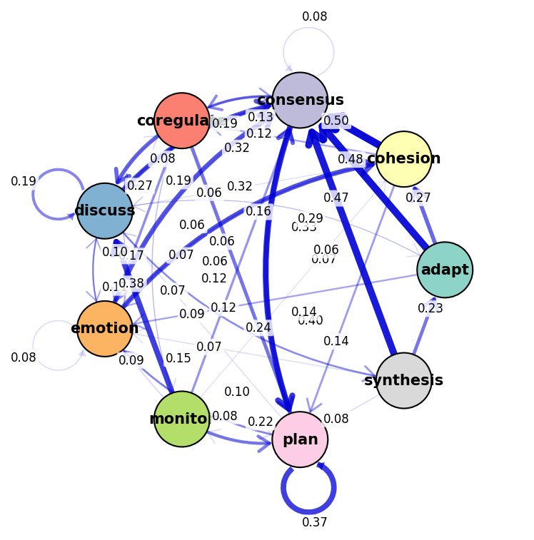

```python
# minimum: hide edges below 0.05; cut: fade edges below 0.1
tna.plot_network(model, minimum=0.05, cut=0.1)
plt.show()
```

### 5.2 Histogram of Edge Weights

Examining the distribution of transition probabilities helps researchers understand the overall structure of the network — whether transitions are uniformly distributed or concentrated among a few strong connections. This informs decisions about pruning thresholds and helps identify the natural "backbone" of the network:

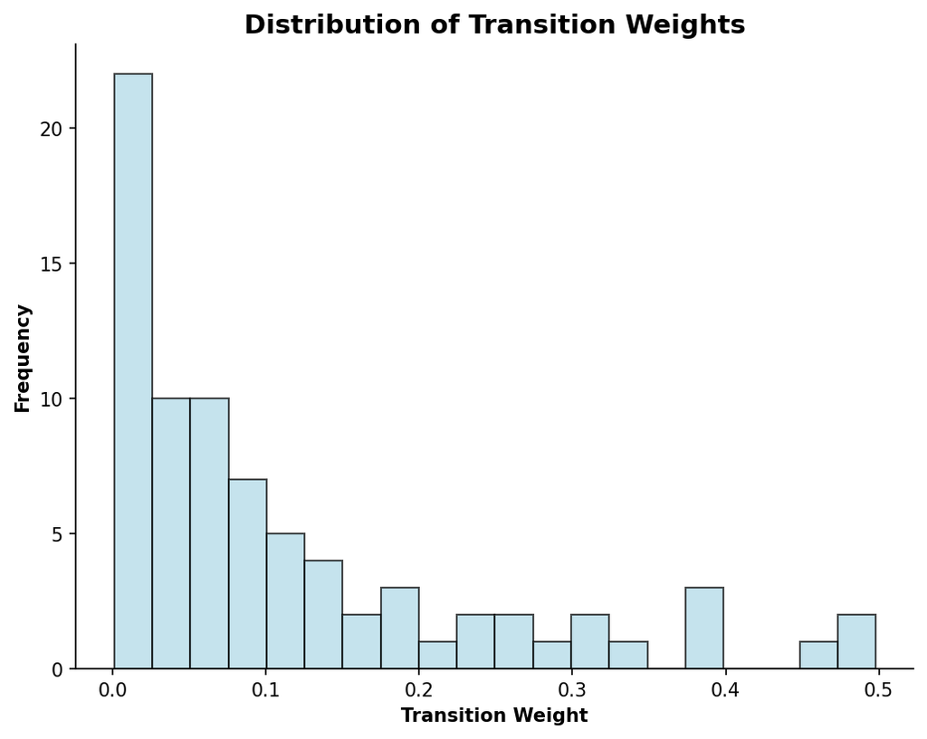

```python
tna.plot_histogram(model)
plt.show()
```